# 601 Project

Game Of Thrones Data Analysis and Visualization

Shruti Shelke and Snehal Prabhu  
5/11/2022

```r
library(readxl)
library(tidyr)
library(tidyverse)
library(ggplot2)
```

## Game of Thrones Dataset

We are using a **Game of Thrones** dataset that keeps record of all the deaths that occur in seasons one through eight. There are a total of 11 variables that describe this dataset. They are the following:

1. order => order of deaths in the show
2. season => which tells us the number of the season for that tuple
3. episode => this gives us the episode number in that particular season that we are viewing deaths for
4. character_killed => the name of the character killed
5. killer => the killer that killed the corresponding character
6. method => how the killer killed the character
7. method_cat => this gives us the category of the method used for killing. For example: if the method is antler, the method_cat would be animal.
8. reason => why the killer killed the victim 9.location => where the victim was killed by the killer
9. allegiance => what house or community they support
10. importance => how important the character killed is, higher the value, greater the importance. Range = [1,4]

## Research Question

Game of thrones is one of our favorite shows. We have invested so much time while watching all the 8 seasons and reading some of the books as well. We wanted to do a fun data analysis project on Game of Thrones where we tried to analyse the deaths of the characters and the battles all the popular houses fought and died for. We tried to plot that information on bar graphs and answer some of the most common questions people have who have watched the show throughout the years and rooted for their favorite house to survive and sit on the iron throne.

## Import the data

Import GOT data set and take a look at the first few rows just to get an idea of the dataset.

```r
library(kableExtra)
GOT_data <- read_excel("GOTdata.xlsx")
kable(head(GOT_data))
```

| order | season | episode | character_killed | killer | method | method_cat | reason | location | allegiance | importance |
| --- | --- | --- | --- | --- | --- | --- | --- | --- | --- | --- |
| 1 | 1 | 1 | Waymar Royce | White Walker | Ice sword | Blade | Unknown | Beyond the Wall | House Royce, Night’s Watch | 2 |
| 2 | 1 | 1 | Gared | White Walker | Ice sword | Blade | Unknown | Beyond the Wall | Night’s Watch | 2 |
| 3 | 1 | 1 | Will | Ned Stark | Sword (Ice) | Blade | Deserting the Night’s Watch | Winterfell | Night’s Watch | 2 |
| 4 | 1 | 1 | Stag | Direwolf | Direwolf teeth | Animal | Unknown | Winterfell | None | 1 |
| 5 | 1 | 1 | Direwolf | Stag | Antler | Animal | Unknown | Winterfell | None | 1 |
| 6 | 1 | 1 | Jon Arryn | Lysa Arryn | Poison | Poison | Petyr Baelish persuaded Lysa to do so for reasons unknown | King’s Landing | House Arryn | 2 |

## Number of Deaths in every Episode:

We want to see how many characters die in every season. To do so, we group by season and then episode. Hence, we get a breakdown of the count of dead characters in every episode of every season.

```r
deaths_by_season <- GOT_data %>%
                    group_by(season, episode)  %>%
                    summarise(count = n())
deaths_by_season$season<-sub("^","Season ",deaths_by_season$season)
deaths_by_season$episode<-sub("^","e",deaths_by_season$episode)
kable(head(deaths_by_season))
```

| season | episode | count |
| --- | --- | --- |
| Season 1 | e1 | 7 |
| Season 1 | e2 | 3 |
| Season 1 | e4 | 1 |
| Season 1 | e5 | 17 |
| Season 1 | e6 | 5 |
| Season 1 | e7 | 5 |

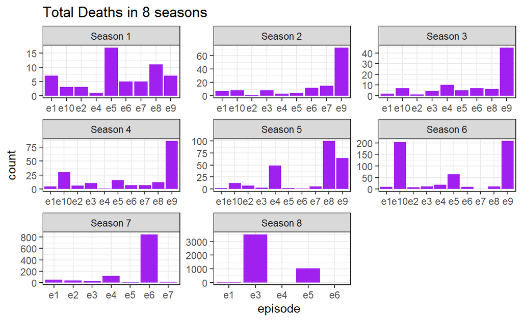

```r
library(forcats)
ggplot(data = deaths_by_season, aes(x = episode, y= count)) +
  geom_bar(stat="identity", fill="purple") +
  facet_wrap(vars(season), scales="free") +
  theme_bw() +
  labs(title="Total Deaths in 8 seasons")
```

## Number of Deaths by Location

we want to see how many deaths occur in each location. Hence we group by location.

```r
death_location <- GOT_data %>% group_by(location) %>% summarise(count_deaths = n()) %>%
                   arrange(desc(count_deaths))
death_location
```

```
# A tibble: 42 x 2
   location        count_deaths
   <chr>                  <int>
 1 Winterfell              3709
 2 King’s Landing          1357
 3 Beyond the Wall          993
 4 Meereen                  154
 5 Goldroad                 116
 6 Hardhome                  99
 7 The Twins                 84
 8 Castle Black              66
 9 Narrow Sea                36
10 Riverlands                31
# ... with 32 more rows
```

## Main Cast

We now want to see how many important characters die over the course of the show. We define the ‘importance’ of characters by the following descriptions:

Death By Importance / Status: Labels : 1 - Soldiers, Knight with least screen time 2 - Less Screen time but nobels or knights like Lannister cousins, Karstarks 3 - Advisors and close to the Lords like Ser Rodrik, Spice Kings beyond the Sea 4 - Main characters, Lords and Ladies of Kingdoms which include Ned Stark, Robert Baratheon, Khal Drogo

```r
death_importance <- GOT_data %>% group_by(importance) %>% summarise(count_importance = n()) %>%
                   arrange(desc(count_importance))

kable(death_importance)
```

| importance | count_importance |
| --- | --- |
| 1 | 6682 |
| 2 | 85 |
| 3 | 75 |
| 4 | 44 |
| NA | 1 |

We see that characters of importance 1 have most deaths as these are generally the extras while characters of importance 4 are significantly lower as not as many important characters died as compared to the extras. Even though it felt like a lot while watching the show.

Let’s work on the main cast:

```r
GOT_maincast <- GOT_data %>% filter(importance==4)

GOT_maincast <- GOT_maincast %>% separate(character_killed, c('Name', 'House')) %>% na.omit()

kable(head(GOT_maincast))
```

| order | season | episode | Name | House | killer | method | method_cat | reason | location | allegiance | importance |
| --- | --- | --- | --- | --- | --- | --- | --- | --- | --- | --- | --- |
| 33 | 1 | 6 | Viserys | Targaryen | Khal Drogo | Molten gold | Fire/Burning | Threatened Daenerys Targaryen and her unborn child, drew his sword in the sacred city | Vaes Dothrak | House Targaryen | 4 |
| 34 | 1 | 7 | Robert | Baratheon | Boar | Tusk | Animal | Hunted the boar while drunk | King’s Landing | House Baratheon of King’s Landing | 4 |
| 56 | 1 | 9 | Ned | Stark | Ilyn Payne | Sword (Ice) | Blade | Executed on Joffrey Baratheon’s orders after Ned claimed Joffrey wasn’t the true heir to the throne | King’s Landing | House Stark | 4 |
| 58 | 1 | 10 | Khal | Drogo | Daenerys Targaryen | Pillow | Household item | Killed after being put into a vegetative state by Mirri Maz Duur | Red Waste | Dothraki | 4 |
| 79 | 2 | 5 | Renly | Baratheon | Melisandre “the Red Woman” of Asshai | Shadow Demon | Magic | Killed so that Stannis Baratheon would have fewer enemies | Storm’s End | House Baratheon of Storm’s End | 4 |
| 199 | 3 | 4 | Jeor | Mormont | Rast | Knife | Blade | Attacked in a mutiny | Beyond the Wall | Night’s Watch, House Mormont | 4 |

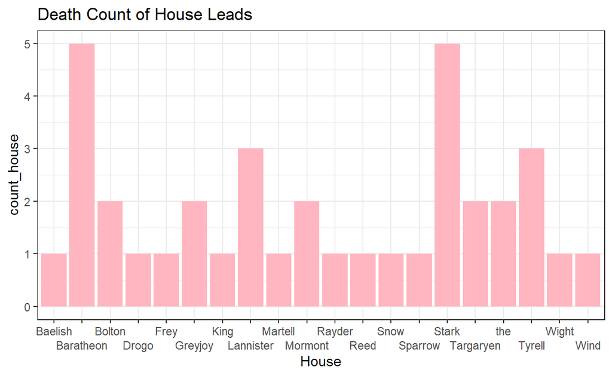

```r
GOT_maincast %>% group_by(House) %>% summarise(count_house = n()) %>%
                arrange(desc(count_house)) %>%
                ggplot(aes(x=House, y=count_house)) +
                geom_bar(stat="identity", fill="lightpink") +
                scale_x_discrete(guide = guide_axis(n.dodge=2)) +
                theme_bw() +
                labs(title = "Death Count of House Leads")
```

Looking at only the major houses of Game of Thrones and how many individuals died that had allegiances to these houses, we see that **Baratheons and Starks** have the most deaths. It is interesting to note that Joffrey, Myrcella and Tommen are considered Baratheons in this dataset and not Lannisters, hence the high death count for Baratheons.

## Assasins

We also tried to plot the top killers/ assassins of all the characters in game of thrones. We see that the white walkers have killed the maximum number of people in the show followed by Drogon in all of 8 seasons.

```r
killers <- GOT_data %>% group_by(killer) %>% summarise(count_killer = n()) %>%
                arrange(desc(count_killer)) %>%
  filter(count_killer >=91)
kable(killers)
```

| killer | count_killer |
| --- | --- |
| Wight | 1602 |
| Drogon | 1426 |
| Arya Stark | 1278 |
| None | 477 |
| Rhaegal | 273 |
| Cersei Lannister | 199 |
| Jon Snow | 112 |
| Stark soldier | 96 |
| Bolton soldier | 91 |

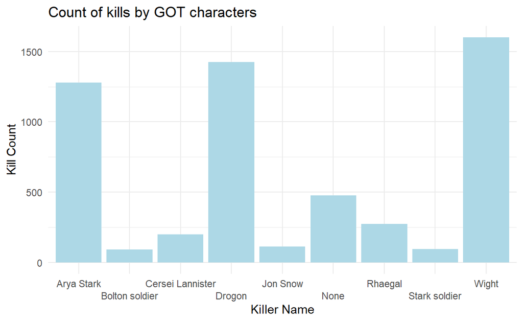

```r
ggplot(killers,aes(x=killer, y=count_killer)) +
geom_col(stat='identity', fill='lightblue') +
scale_x_discrete(guide = guide_axis(n.dodge=2)) +
theme_minimal() +
labs(x = "Killer Name", y = "Kill Count",title = "Count of kills by GOT characters")
```

## Biblography

**Dataset**: https://www.washingtonpost.com/graphics/entertainment/game-of-thrones/

Valar Morghulis.